# Hard Rock Hotel and Casino in Atlantic City Social Media Analysis

## Nicholas Branco

This is the second part of my analysis of Hard Rock Hotel and Casino's social media analysis.

### The Journey so Far

I began working at Hard Rock Hotel and Casino in Atlantic City on April 23, 2018 while working on my Master's degree in Data Science and Strategical analytics at Stockton University. I completed my semester with a project on a social media analysis of a network on Twitter focusing on anorexia. This got me thinking of my workplace's social media activity.

I found the Twitter page for Hard Rock...and it did not seem to be too active, suprisingly. I thought for sure that they would want to be druming up the hype for the new opening (the Atlantic City property was set to open on June 28, 2018), but it seemed like they didn't even care. I chalked this up to being too far from opening, though not much changed when I checked again a couple of weeks later.

Thus, I decided to look at the network over a few weeks, from before opening until after. This process is detailed in the R Notebook I have, though I will summarize here. I used Rtweet to collect data on Hard Rock's Twitter data nine times over a period of a month and a half. I tried to provide enough overlap so as to not miss any tweets. I then combined all of these datasets into one (well, two) and forced them to be unique. All of this was done in R, so now I want to finish the project in python.

### Reading in the Data

Like in R, I will be using feather to transfer the data.

```python
import feather

tweets = feather.read_dataframe( "tweets" )
users  = feather.read_dataframe( "users"  )
```

```python
tweets
```

|  | screen_name | text | created_at |
| --- | --- | --- | --- |
| 0 | 324cat | Hard Rock preveu contractar més de 2.000 treba... | 2018-05-25 16:02:00+00:00 |
| 1 | LasVegasSoul | Tickets are on sale NOW for the Miseducation o... | 2018-06-04 03:05:02+00:00 |
| 2 | jbatt52 | #whereareyouplaying Seminole Hard Rock Casino ... | 2018-06-04 02:43:36+00:00 |
| 3 | eden_shireen | Eden Shireen has a show on 06/05/2018 at 06:00... | 2018-06-04 02:08:42+00:00 |
| 4 | RenzoGracieBJJ | RT @MarkTaffetMedia: Coach @DanMiller185 looks... | 2018-06-04 02:04:26+00:00 |
| 5 | RenzoGracieBJJ | RT @MarkTaffetMedia: Coach @DanielGracie looks... | 2018-06-04 02:04:22+00:00 |
| 6 | CSSRadio | RT @MarkTaffetMedia: @CSSRadio Follow me and t... | 2018-06-04 01:59:20+00:00 |
| 7 | MarkTaffetMedia | @CSSRadio Follow me and then let’s PM about a ... | 2018-06-04 01:35:13+00:00 |
| 8 | CSSRadio | RT @MarkTaffetMedia: Coach @DanielGracie looks... | 2018-06-04 01:19:31+00:00 |
| 9 | ERSA_Soldering | Kurtz Ersa Inc. &amp; Comtree to participate i... | 2018-06-03 22:01:36+00:00 |
| 10 | iM_Shep | RT @jetlife_javares: Hard rock casino waitress... | 2018-06-03 21:11:06+00:00 |
| 11 | LasVegasSoul | Cedric the Entertainer performing LIVE @TheJoi... | 2018-06-03 20:40:04+00:00 |
| 12 | sanchez_sampe | @DefiantVictory @TheEconomist Well, irá not ha... | 2018-06-03 20:06:12+00:00 |
| 13 | USShrinkWrap | @USShrinkWrap is proud to be working on the 36... | 2018-06-03 19:27:30+00:00 |
| 14 | robinsportsnews | RT @JillaineOwens: Hard Rock's NFL partnership... | 2018-06-03 19:25:04+00:00 |
| 15 | LasVegasSoul | Tickets available NOW for Ms. Lauryn Hill's LI... | 2018-06-03 19:20:05+00:00 |
| 16 | AdamLoebSmall | RT @JillaineOwens: Hard Rock's NFL partnership... | 2018-06-03 19:10:34+00:00 |
| 17 | VictorRocha1 | RT @JillaineOwens: Hard Rock's NFL partnership... | 2018-06-03 19:09:20+00:00 |
| 18 | hamondabone11 | I might go to @TBSOfficial at The Joint at Har... | 2018-06-03 18:58:53+00:00 |
| 19 | metalman1767 | I added a video to a @YouTube playlist https:/... | 2018-06-03 18:55:12+00:00 |
| 20 | TheDealMountain | Get to Hard Rock Hotel and Casino (Biloxi) - G... | 2018-06-03 18:51:07+00:00 |
| 21 | MarkTaffetMedia | @inward_look @MMAPRO_LEAGUE @marc_raimondi @MM... | 2018-06-03 18:30:14+00:00 |
| 22 | marinamazz1 | I might go to @maroon5 at Hard Rock Hotel Casi... | 2018-06-03 17:57:08+00:00 |
| 23 | KEV702 | Wale today , Let’s GO! — at Hard Rock Hotel an... | 2018-06-03 17:43:36+00:00 |
| 24 | Hani_Darwish1 | RT @MMAPRO_LEAGUE: Tickets For MMAPL’s debut e... | 2018-06-03 17:39:34+00:00 |
| 25 | Hani_Darwish1 | RT @MarkTaffetMedia: Coach @DanMiller185 looks... | 2018-06-03 17:38:40+00:00 |
| 26 | Hani_Darwish1 | RT @MarkTaffetMedia: Coach @DanielGracie looks... | 2018-06-03 17:38:36+00:00 |
| 27 | MMAPRO_LEAGUE | RT @MarkTaffetMedia: @MMAPRO_LEAGUE Team NJ co... | 2018-06-03 17:37:03+00:00 |
| 28 | MMAPRO_LEAGUE | RT @MarkTaffetMedia: Coach @DanMiller185 looks... | 2018-06-03 17:36:56+00:00 |
| 29 | MMAPRO_LEAGUE | RT @MarkTaffetMedia: Coach @DanielGracie looks... | 2018-06-03 17:36:49+00:00 |
| ... | ... | ... | ... |
| 9331 | djbabylac | LIVING MY BEST LIFE ( @lilduval VOICE) #TAMPA... | 2018-07-12 06:32:46+00:00 |
| 9332 | MIKEYVIP | Do I know any1 at Vinyl Las Vegas inside Hard ... | 2018-07-12 05:58:46+00:00 |
| 9333 | RussianRealtor1 | Новый Отель/Казино «The Seminole Hard Rock Hot... | 2018-07-12 04:31:30+00:00 |
| 9334 | NEO_Scan | Northfield Village: Two males fighting, Hard R... | 2018-07-12 04:23:29+00:00 |
| 9335 | rubiaa_7 | RT @DaInfamouzJ: Seminole Hard Rock Hotel &amp... | 2018-07-12 04:16:31+00:00 |
| 9336 | bchapsports | Report: Hard Rock Atlantic City could soon bec... | 2018-07-12 04:07:50+00:00 |
| 9337 | Santiagoaristi | I'm going to @scorpions at Seminole Hard Rock ... | 2018-07-12 04:04:31+00:00 |
| 9338 | kitty4hawks | RT @seasolshades: @kitty4hawks @DonnaFins @Har... | 2018-07-12 03:29:13+00:00 |
| 9339 | DuBonaire | I miss the strip clubs and the smell of hard r... | 2018-07-12 03:22:01+00:00 |
| 9340 | seasolshades | @kitty4hawks @DonnaFins @HarleyEnthusia2 @Cher... | 2018-07-12 03:19:40+00:00 |
| 9341 | veta324 | @JaredLeto @ShannonLeto @30SECONDSTOMARS @Stev... | 2018-07-12 03:12:13+00:00 |
| 9342 | LasVegasSoul | Miseducation of Lauryn Hill Concert @TheJointL... | 2018-07-12 03:05:03+00:00 |
| 9343 | TheCoreRocksNJ | The Jersey Wing of the Hard Rock Casino in AC.... | 2018-07-12 02:06:51+00:00 |
| 9344 | Joseevita | Something old, something new, something borrow... | 2018-07-12 02:05:34+00:00 |
| 9345 | captaincalv | #hardrock @ Seminole Hard Rock Hotel &amp; Cas... | 2018-07-12 01:22:38+00:00 |
| 9346 | captaincalv | #hardrock @ Seminole Hard Rock Hotel &amp; Cas... | 2018-07-12 01:18:29+00:00 |
| 9347 | Guitarra_Nachos | Hard Rock Hotel and Casino Las Vegas\nGo on...... | 2018-07-12 01:05:26+00:00 |
| 9348 | StaleeA | living lavish over here in paradise 💋🌴 @ Hard ... | 2018-07-12 00:43:27+00:00 |
| 9349 | TheEnginseer | @WSJ @HolmanJenkins "We've come to the Atlanti... | 2018-07-12 00:39:35+00:00 |
| 9350 | waterscpagroup | Seminole Hard Rock Casino can add craps and ro... | 2018-07-12 00:34:44+00:00 |
| 9351 | WTFtv | Here’s @goddesofmusic87 with the legendary ver... | 2018-07-12 00:34:38+00:00 |
| 9352 | WTFtv | Here with the lovely @shiriallwood at @AEexpo ... | 2018-07-12 00:34:15+00:00 |
| 9353 | RWOMC | "RT NJGOP: Chairman DSteinhardtEsq, Assembly L... | 2018-07-12 00:09:54+00:00 |
| 9354 | CarolynBarrett4 | RT @PhillyInquirer: Hard Rock casino and Bet36... | 2018-07-10 18:08:59+00:00 |
| 9355 | lex6m | Cautiously optimistic\n\nhttps://t.co/ICGz7D2ahV | 2018-07-10 15:46:54+00:00 |
| 9356 | DealTwee | Get to Hard Rock Hotel and Casino (Biloxi) - G... | 2018-07-10 13:12:17+00:00 |
| 9357 | saywhatjennjenn | RT @CarlosWPLG: #RIGHT #NOW The final beam is ... | 2018-07-09 16:29:59+00:00 |
| 9358 | TopHotelBooker | Hard Rock #Hotel &amp; #Casino Biloxi, 🌟🌟🌟🌟🌟\... | 2018-07-08 11:00:23+00:00 |
| 9359 | AliceLaArmy1103 | RT @billboard: Elvis, Beatles and more memorab... | 2018-07-07 19:56:01+00:00 |
| 9360 | cubfancurt | RT @billboard: Elvis, Beatles and more memorab... | 2018-07-07 19:30:29+00:00 |

9361 rows × 3 columns

```python
users
```

|  | user_id | name | screen_name | location | description | url | protected | followers_count | friends_count | listed_count | statuses_count | favourites_count | account_created_at | verified | profile_url | profile_expanded_url | account_lang | profile_banner_url | profile_background_url | profile_image_url |
| --- | --- | --- | --- | --- | --- | --- | --- | --- | --- | --- | --- | --- | --- | --- | --- | --- | --- | --- | --- | --- |
| 0 | 8330472 | 324.cat | 324cat | Barcelona | Tot el que vols saber, quan ho vols saber. Seg... | https://t.co/ZNcVUlOvnh | False | 510476 | 301 | 5106 | 265311 | 2 | 2007-08-21 14:03:19+00:00 | True | https://t.co/ZNcVUlOvnh | http://www.324.cat | ca | https://pbs.twimg.com/profile_banners/8330472/... | http://abs.twimg.com/images/themes/theme1/bg.png | http://pbs.twimg.com/profile_images/8995771797... |
| 1 | 626846910 | Las Vegas SOUL | LasVegasSoul | Las Vegas, NV | https://t.co/diS9HJs2tL is the Soul of the Str... | https://t.co/gKzJTRNrD5 | False | 3036 | 2635 | 153 | 71118 | 1146 | 2012-07-04 20:37:39+00:00 | False | https://t.co/gKzJTRNrD5 | http://www.lasvegassoul.com | en | https://pbs.twimg.com/profile_banners/62684691... | http://abs.twimg.com/images/themes/theme1/bg.png | http://pbs.twimg.com/profile_images/8878163962... |
| 2 | 212776640 | James Battersby | jbatt52 | Tampa Florida | Check us out @SHRTPoker | None | False | 161 | 246 | 5 | 327 | 121 | 2010-11-07 01:15:25+00:00 | False | None | None | en | https://pbs.twimg.com/profile_banners/21277664... | http://abs.twimg.com/images/themes/theme1/bg.png | http://pbs.twimg.com/profile_images/6356844572... |
| 3 | 2209525259 | Eden Shireen | eden_shireen | Tampa, Florida | I like to view life a little differently than ... | https://t.co/pMC5v8bMvV | False | 1529 | 2098 | 10 | 3908 | 7407 | 2013-12-05 23:38:00+00:00 | False | https://t.co/pMC5v8bMvV | http://www.edenshireen.com | en | https://pbs.twimg.com/profile_banners/22095252... | http://abs.twimg.com/images/themes/theme17/bg.gif | http://pbs.twimg.com/profile_images/6925884775... |
| 4 | 60211263 | Renzo_Gracie_BJJ | RenzoGracieBJJ | NYC | MMA Fighter, BJJ Master, & Entrepreneur. Renzo... | http://t.co/QV4ANZIfW1 | False | 224171 | 4076 | 2039 | 141719 | 35911 | 2009-07-26 02:34:00+00:00 | True | http://t.co/QV4ANZIfW1 | http://www.renzogracie.com | en | None | http://abs.twimg.com/images/themes/theme9/bg.gif | http://pbs.twimg.com/profile_images/1134287569... |
| 5 | 541140135 | CageSideSubmssions | CSSRadio | philadelphia,pa | Host of Cage Side Submissions every Sunday 8-1... | https://t.co/urNiu2wIct | False | 17571 | 14325 | 349 | 272721 | 48378 | 2012-03-30 19:06:51+00:00 | False | https://t.co/urNiu2wIct | https://www.theterphouse.com/shop | en | https://pbs.twimg.com/profile_banners/54114013... | http://abs.twimg.com/images/themes/theme9/bg.gif | http://pbs.twimg.com/profile_images/8663747377... |
| 6 | 4378827076 | Mark Taffet | MarkTaffetMedia | New Jersey, USA | Pres of MMA PRO LEAGUE. Mgr of world's #1 Clar... | None | False | 1085 | 243 | 9 | 1208 | 2034 | 2015-12-05 03:16:41+00:00 | False | None | None | en | https://pbs.twimg.com/profile_banners/43788270... | http://abs.twimg.com/images/themes/theme1/bg.png | http://pbs.twimg.com/profile_images/6732362822... |
| 7 | 89208272 | ERSA (has) | ERSA_Soldering | Wertheim, Germany | Löttechnik: Maschinen, Werkzeuge, Drucker\r\ns... | http://t.co/uucWUO7QES | False | 798 | 779 | 0 | 789 | 146 | 2009-11-11 15:26:46+00:00 | False | http://t.co/uucWUO7QES | http://www.ersa.de | de | https://pbs.twimg.com/profile_banners/89208272... | http://abs.twimg.com/images/themes/theme1/bg.png | http://pbs.twimg.com/profile_images/7538712787... |
| 8 | 59931546 | $hep | iM_Shep | iSleepInMyCar | iM Just Shep!!!! Life Ain't Easy And A Easy Li... | None | False | 1754 | 3472 | 3 | 42571 | 4522 | 2009-07-25 00:30:34+00:00 | False | None | None | en | https://pbs.twimg.com/profile_banners/59931546... | http://abs.twimg.com/images/themes/theme14/bg.gif | http://pbs.twimg.com/profile_images/9330713612... |
| 9 | 985293024853942272 | David Sánchez sampe | sanchez_sampe |  |  | None | False | 1 | 22 | 0 | 23 | 1 | 2018-04-14 23:05:37+00:00 | False | None | None | es | None | None | http://pbs.twimg.com/profile_images/1000461050... |
| 10 | 24605586 | US Shrink Wrap, Inc | USShrinkWrap | Plymouth Meeting, PA | US Shrink Wrap is a unique nationwide contract... | https://t.co/tqUv5QmDuh | False | 318 | 1167 | 0 | 149 | 87 | 2009-03-15 23:13:38+00:00 | False | https://t.co/tqUv5QmDuh | https://www.usshrinkwrapinc.com | en | https://pbs.twimg.com/profile_banners/24605586... | http://abs.twimg.com/images/themes/theme2/bg.gif | http://pbs.twimg.com/profile_images/5068276563... |
| 11 | 336437711 | Sports News & Videos | robinsportsnews | RT's Are FYI Purposes Only | Join http://t.co/tFgwIuOAlo for the best Sport... | http://t.co/RskLQwUqp7 | False | 9128 | 7265 | 268 | 777115 | 19 | 2011-07-16 08:50:59+00:00 | False | http://t.co/RskLQwUqp7 | http://www.robinspost.com/news/sports-news.html | en | https://pbs.twimg.com/profile_banners/33643771... | http://abs.twimg.com/images/themes/theme14/bg.gif | http://pbs.twimg.com/profile_images/2240592273... |
| 12 | 17749808 | Adam Small | AdamLoebSmall | Johns Creek, GA | Professional dad (x3). Tennis junkie. Vanderbi... | https://t.co/t6vZ1cxoSE | False | 1742 | 547 | 61 | 11927 | 14241 | 2008-11-30 05:45:00+00:00 | False | https://t.co/t6vZ1cxoSE | http://www.adamsmall.com | en | https://pbs.twimg.com/profile_banners/17749808... | http://abs.twimg.com/images/themes/theme1/bg.png | http://pbs.twimg.com/profile_images/8847833861... |
| 13 | 18072119 | Victor Rocha | VictorRocha1 | Temecula, CA | Editor of https://t.co/HhUmD81OUO Conference... | https://t.co/Pf37rt8QVw | False | 3945 | 1826 | 0 | 38239 | 9568 | 2008-12-12 07:12:46+00:00 | False | https://t.co/Pf37rt8QVw | http://pechanga.net | en | https://pbs.twimg.com/profile_banners/18072119... | http://abs.twimg.com/images/themes/theme15/bg.png | http://pbs.twimg.com/profile_images/6148733146... |
| 14 | 1516455709 | Hambonia | hamondabone11 | Las Vegas, NV | #BIRDIESANDERS #RITTZBITCH #YA-UHYEAH #CLINTE... | None | False | 394 | 926 | 2 | 5996 | 3625 | 2013-06-14 13:22:37+00:00 | False | None | None | en | https://pbs.twimg.com/profile_banners/15164557... | http://abs.twimg.com/images/themes/theme1/bg.png | http://pbs.twimg.com/profile_images/7364678137... |
| 15 | 164458859 | Josh | metalman1767 | Florida | Music lover & concert goer. I enjoy going to c... | https://t.co/ZeSuyjYQ6f | False | 19 | 30 | 0 | 895 | 1 | 2010-07-08 23:04:02+00:00 | False | https://t.co/ZeSuyjYQ6f | https://www.youtube.com/user/metalman1767 | en | https://pbs.twimg.com/profile_banners/16445885... | http://abs.twimg.com/images/themes/theme1/bg.png | http://pbs.twimg.com/profile_images/2397871729... |
| 16 | 984987709151232000 | Deal Mountain | TheDealMountain |  |  | None | False | 1 | 7 | 0 | 1811 | 0 | 2018-04-14 02:52:24+00:00 | False | None | None | en | None | None | http://pbs.twimg.com/profile_images/9860187366... |
| 17 | 27481558 | Marina Mazzone | marinamazz1 | 🎶 | taylor swift wiped my tears and told me I was ... | https://t.co/qv5Ixt09G1 | False | 1239 | 931 | 24 | 81980 | 91105 | 2009-03-29 19:06:56+00:00 | False | https://t.co/qv5Ixt09G1 | https://vsco.co/marinamazz1 | en | https://pbs.twimg.com/profile_banners/27481558... | http://abs.twimg.com/images/themes/theme13/bg.gif | http://pbs.twimg.com/profile_images/9100745028... |
| 18 | 27791968 | KEV702 | KEV702 | Las Vegas, NV | Good Vibes Only. Work Hard, Stay Humble, Be YO... | https://t.co/mJSW43fqtx | False | 6885 | 3872 | 81 | 48875 | 2059 | 2009-03-31 02:24:52+00:00 | False | https://t.co/mJSW43fqtx | http://Instagram.com/kev702 | en | https://pbs.twimg.com/profile_banners/27791968... | http://abs.twimg.com/images/themes/theme1/bg.png | http://pbs.twimg.com/profile_images/8038582170... |
| 19 | 522231637 | Hani Darwish | Hani_Darwish1 | NJ/NY-Worldwide | CEO of MMA PRO LEAGUE. Former President of EFC... | https://t.co/YlYy0GJXxH | False | 43710 | 581 | 7 | 765 | 613 | 2012-03-12 13:02:30+00:00 | False | https://t.co/YlYy0GJXxH | http://mmaproleague.com | en | https://pbs.twimg.com/profile_banners/52223163... | http://abs.twimg.com/images/themes/theme14/bg.gif | http://pbs.twimg.com/profile_images/3788000005... |
| 20 | 996777659618201600 | MMA PRO LEAGUE | MMAPRO_LEAGUE | New Jersey, USA | MMA PRO LEAGUE where iconic head coaches lead ... | https://t.co/8Qw1UdSoyp | False | 154 | 11 | 2 | 22 | 37 | 2018-05-16 15:41:28+00:00 | False | https://t.co/8Qw1UdSoyp | http://www.mmaproleague.com | en | https://pbs.twimg.com/profile_banners/99677765... | None | http://pbs.twimg.com/profile_images/9967785016... |
| 21 | 336266462 | Treeza parmer🇺🇸🌹 | TreezaParmer | California, USA |  | None | False | 135 | 82 | 1 | 1805 | 12556 | 2011-07-16 00:52:39+00:00 | False | None | None | en | https://pbs.twimg.com/profile_banners/33626646... | http://abs.twimg.com/images/themes/theme1/bg.png | http://pbs.twimg.com/profile_images/1002362109... |
| 22 | 4544109078 | CapeAtlanticNews | CapeAtlanticNWS |  | Sharing news and updates from Atlantic and Cap... | None | False | 122 | 498 | 9 | 39874 | 30 | 2015-12-13 04:57:11+00:00 | False | None | None | en | https://pbs.twimg.com/profile_banners/45441090... | None | http://pbs.twimg.com/profile_images/7936832504... |
| 23 | 19074331 | Press of AC | ThePressofAC | Atlantic City, New Jersey | The latest news for Atlantic City and the surr... | http://t.co/8YaO09BkXB | False | 152605 | 254 | 288 | 43026 | 82 | 2009-01-16 16:42:47+00:00 | False | http://t.co/8YaO09BkXB | http://pressofac.com | en | https://pbs.twimg.com/profile_banners/19074331... | http://abs.twimg.com/images/themes/theme2/bg.gif | http://pbs.twimg.com/profile_images/6974971667... |
| 24 | 3398852931 | VBWFF | VeroBeachWFF |  |  | None | False | 122 | 93 | 2 | 976 | 17 | 2015-08-01 16:17:36+00:00 | False | None | None | en | https://pbs.twimg.com/profile_banners/33988529... | http://abs.twimg.com/images/themes/theme1/bg.png | http://pbs.twimg.com/profile_images/6275152287... |
| 25 | 925631785 | Tom Kelly | j5jobs |  |  | None | False | 21 | 86 | 2 | 595 | 628 | 2012-11-04 16:06:58+00:00 | False | None | None | en | https://pbs.twimg.com/profile_banners/92563178... | http://abs.twimg.com/images/themes/theme1/bg.png | http://pbs.twimg.com/profile_images/4235752158... |
| 26 | 2722108045 | KOBSCH EDGAR | EDXXX3 | Abbeville, Picardie | Fan of Boy George and Culture Club since 1982 ... | None | False | 538 | 785 | 2 | 1625 | 7920 | 2014-08-10 17:21:59+00:00 | False | None | None | fr | https://pbs.twimg.com/profile_banners/27221080... | http://abs.twimg.com/images/themes/theme8/bg.gif | http://pbs.twimg.com/profile_images/9776560415... |
| 27 | 738095624508297216 | Dorian Golej | GolejDorian |  | Public diary scifi tales of a developer fact &... | None | False | 321 | 2750 | 1 | 7646 | 211 | 2016-06-01 19:51:24+00:00 | False | None | None | en | https://pbs.twimg.com/profile_banners/73809562... | http://abs.twimg.com/images/themes/theme1/bg.png | http://pbs.twimg.com/profile_images/7698920954... |
| 28 | 3924259581 | LegallyBae | legallybae | New York, NY | Followed by: @soledadobrien @sffed @texanschee... | None | False | 3132 | 4546 | 213 | 465852 | 35547 | 2015-10-11 03:52:46+00:00 | False | None | None | en | https://pbs.twimg.com/profile_banners/39242595... | http://abs.twimg.com/images/themes/theme1/bg.png | http://pbs.twimg.com/profile_images/1002608577... |
| 29 | 95458172 | Dan Miller | DanMiller185 | NJ |  | http://t.co/ebFPZj0kpw | False | 35564 | 167 | 511 | 844 | 331 | 2009-12-08 17:02:32+00:00 | True | http://t.co/ebFPZj0kpw | http://www.millerbrothersmma.com | en | None | http://abs.twimg.com/images/themes/theme14/bg.gif | http://pbs.twimg.com/profile_images/2584120306... |
| ... | ... | ... | ... | ... | ... | ... | ... | ... | ... | ... | ... | ... | ... | ... | ... | ... | ... | ... | ... | ... |
| 12173 | 247067129 | Jobs in Vancouver BC | Vancouver__jobs | Canada | New jobs in Vancouver, British Columbia, direc... | http://t.co/5vul5i3LAq | False | 3590 | 375 | 168 | 165668 | 11 | 2011-02-04 01:05:21+00:00 | False | http://t.co/5vul5i3LAq | http://www.eluta.ca/search?l=Vancouver+BC | en | https://pbs.twimg.com/profile_banners/24706712... | http://abs.twimg.com/images/themes/theme1/bg.png | http://pbs.twimg.com/profile_images/1234156274... |
| 12174 | 164562937 | Cavs4Life | Akrzips2012 | Cleveland, OH | Cleveland sports fan. | None | False | 33 | 306 | 1 | 2106 | 9 | 2010-07-09 04:59:48+00:00 | False | None | None | en | https://pbs.twimg.com/profile_banners/16456293... | http://abs.twimg.com/images/themes/theme1/bg.png | http://pbs.twimg.com/profile_images/1017556411... |
| 12175 | 593364363 | BodyGraphics Photo | BodyGraphicsPho | Fort Worth, TX | BodyGraphics Photography by Lloyd Terry Jr. is... | https://t.co/aMQi2FUN0Y | False | 3153 | 1335 | 4 | 1624 | 18 | 2012-05-29 02:43:15+00:00 | False | https://t.co/aMQi2FUN0Y | http://bodygraphicsphotography.com | en | https://pbs.twimg.com/profile_banners/59336436... | http://abs.twimg.com/images/themes/theme16/bg.gif | http://pbs.twimg.com/profile_images/4601790640... |
| 12176 | 3179996244 | DeltaGoodremNews | deltagoodnews | WORLD | I am just a fan. Instagram: @deltagoodnew http... | None | False | 1564 | 3012 | 29 | 16590 | 36533 | 2015-04-30 00:00:39+00:00 | False | None | None | es | https://pbs.twimg.com/profile_banners/31799962... | http://abs.twimg.com/images/themes/theme1/bg.png | http://pbs.twimg.com/profile_images/7294544906... |
| 12177 | 243481992 | Q | SaintQ_ | Sunrise Manor, NV | snap: thehomieq \n20 and tired | https://t.co/SbX2cNqw9g | False | 1192 | 609 | 10 | 51334 | 9681 | 2011-01-27 04:06:29+00:00 | False | https://t.co/SbX2cNqw9g | http://instagram.com/invader_q | en | https://pbs.twimg.com/profile_banners/24348199... | http://abs.twimg.com/images/themes/theme14/bg.gif | http://pbs.twimg.com/profile_images/9930108580... |
| 12178 | 26175587 | Mat D | Mat_D | Sioux Falls, SD | Singer/songwriter Mathew deRiso Sioux Falls So... | https://t.co/SUTTnBQ9hM | False | 573 | 923 | 14 | 6924 | 3152 | 2009-03-24 04:13:44+00:00 | False | https://t.co/SUTTnBQ9hM | http://www.MatdandtheProfaneSaints.com | en | https://pbs.twimg.com/profile_banners/26175587... | http://abs.twimg.com/images/themes/theme14/bg.gif | http://pbs.twimg.com/profile_images/1008468032... |
| 12179 | 990268911793864705 | donnatownsend | townsend19944 | California | Am Donna am a good looking Lady with God feari... | None | False | 83 | 929 | 0 | 182 | 127 | 2018-04-28 16:38:01+00:00 | False | None | None | en | https://pbs.twimg.com/profile_banners/99026891... | None | http://pbs.twimg.com/profile_images/9920258559... |
| 12180 | 442583715 | eConnect™ | econnectinc | Las Vegas, Nevada | Big Data, BI, Exception Reporting, Surveillanc... | http://t.co/Mob3ig3x0w | False | 1374 | 545 | 12 | 614 | 236 | 2011-12-21 07:55:07+00:00 | False | http://t.co/Mob3ig3x0w | http://www.econnectglobal.com | en | https://pbs.twimg.com/profile_banners/44258371... | http://abs.twimg.com/images/themes/theme14/bg.gif | http://pbs.twimg.com/profile_images/3788000006... |
| 12181 | 74028902 | Gaby Salgado | gabysalgado07 |  |  | None | False | 165 | 189 | 1 | 9312 | 19259 | 2009-09-14 01:32:20+00:00 | False | None | None | en | https://pbs.twimg.com/profile_banners/74028902... | http://abs.twimg.com/images/themes/theme1/bg.png | http://pbs.twimg.com/profile_images/5119751798... |
| 12182 | 74689949 | Cian Coey | CayenneCoey | Las Vegas, NV | Singer for Dweezil Zappa. Singer for Meat Loaf... | https://t.co/grX4kU1ccA | False | 755 | 179 | 6 | 287 | 303 | 2009-09-16 09:12:50+00:00 | False | https://t.co/grX4kU1ccA | http://www.reverbnation.com/ciancoey | en | https://pbs.twimg.com/profile_banners/74689949... | http://abs.twimg.com/images/themes/theme1/bg.png | http://pbs.twimg.com/profile_images/9984853584... |
| 12183 | 1014459858 | Victoria Elizabeth | torsisbarro |  | iHeart Media National Programming Executive In... | None | False | 561 | 799 | 3 | 13818 | 6322 | 2012-12-16 04:22:18+00:00 | False | None | None | en | https://pbs.twimg.com/profile_banners/10144598... | http://abs.twimg.com/images/themes/theme1/bg.png | http://pbs.twimg.com/profile_images/1014886592... |
| 12184 | 2329747886 | Pretty Odd Wieners | PrettyOddWiener | South Lake Tahoe, CA | Jumbo Hot Dogs & Exotic Sausages! Roadrunner 7... | https://t.co/KFFrQEV7Q9 | False | 109 | 79 | 2 | 380 | 3030 | 2014-02-06 04:35:24+00:00 | False | https://t.co/KFFrQEV7Q9 | http://prettyoddwieners.com/ | en | https://pbs.twimg.com/profile_banners/23297478... | http://abs.twimg.com/images/themes/theme1/bg.png | http://pbs.twimg.com/profile_images/9548412977... |
| 12185 | 812080701730263040 | PlayUSA.com | PlayUSAnews | USA | News and info on regulated, legal casino gamin... | https://t.co/yvuVNGxgop | False | 1478 | 22 | 7 | 3103 | 63 | 2016-12-22 23:41:41+00:00 | False | https://t.co/yvuVNGxgop | http://www.playusa.com | en | https://pbs.twimg.com/profile_banners/81208070... | http://abs.twimg.com/images/themes/theme1/bg.png | http://pbs.twimg.com/profile_images/8271522886... |
| 12186 | 69107971 | cody | komokasi | new york | Under construction. Please watch your step. En... | None | False | 96 | 203 | 0 | 324 | 123 | 2009-08-26 21:55:48+00:00 | False | None | None | en | https://pbs.twimg.com/profile_banners/69107971... | http://abs.twimg.com/images/themes/theme5/bg.gif | http://pbs.twimg.com/profile_images/5490450784... |
| 12187 | 107259865 | Tahoe Chamber | TahoeChamber | South Lake Tahoe, CA/NV | Tahoe Chamber is the leading voice of business... | https://t.co/i23G9SsYl8 | False | 3955 | 1949 | 107 | 4193 | 863 | 2010-01-22 00:49:03+00:00 | False | https://t.co/i23G9SsYl8 | http://www.tahoechamber.org | en | https://pbs.twimg.com/profile_banners/10725986... | http://abs.twimg.com/images/themes/theme1/bg.png | http://pbs.twimg.com/profile_images/9291466544... |
| 12188 | 1616249606 | Frank O’neal Meadows | FrankMeadows84 | Los Angeles, CA | Boring, bisexual, California dude bro. I’m all... | None | False | 152 | 307 | 3 | 20080 | 25229 | 2013-07-23 22:30:21+00:00 | False | None | None | en | https://pbs.twimg.com/profile_banners/16162496... | http://abs.twimg.com/images/themes/theme1/bg.png | http://pbs.twimg.com/profile_images/9685232950... |
| 12189 | 3181998248 | Kathryn Nickel | Kathryn7Nickel |  | PT ❤️Hairdresser ✨Fitness👟Athlete👙Pilates Stot... | https://t.co/ULIqFmDosM | False | 734 | 644 | 43 | 2908 | 380 | 2015-05-01 17:22:44+00:00 | False | https://t.co/ULIqFmDosM | https://kathrynn.isagenix.com/ | en | https://pbs.twimg.com/profile_banners/31819982... | http://abs.twimg.com/images/themes/theme1/bg.png | http://pbs.twimg.com/profile_images/8269519652... |
| 12190 | 3358990977 | Tata Batista🗽 | TataBatista9 |  | Born in NJ.Princeton University.NJ.USA. | None | False | 579 | 721 | 5 | 14025 | 7953 | 2015-07-04 17:49:13+00:00 | False | None | None | en | https://pbs.twimg.com/profile_banners/33589909... | http://abs.twimg.com/images/themes/theme1/bg.png | http://pbs.twimg.com/profile_images/8718870796... |
| 12191 | 16211673 | GotoBus | GotoBus | Cambridge, MA | Book bus tickets online to hundreds of destina... | https://t.co/Z9mNbodczp | False | 3930 | 3513 | 90 | 3212 | 81 | 2008-09-09 21:31:54+00:00 | False | https://t.co/Z9mNbodczp | http://www.gotobus.com | en | https://pbs.twimg.com/profile_banners/16211673... | http://abs.twimg.com/images/themes/theme1/bg.png | http://pbs.twimg.com/profile_images/5988936424... |
| 12192 | 705211495 | Shifting Gears | only1ACInsider | Atlantic City NJ | Floridian, the son of a Florida Cracker - Fort... | None | False | 1415 | 4914 | 21 | 6010 | 3146 | 2012-07-19 14:54:24+00:00 | False | None | None | en | https://pbs.twimg.com/profile_banners/70521149... | http://abs.twimg.com/images/themes/theme15/bg.png | http://pbs.twimg.com/profile_images/9990818671... |
| 12193 | 256747822 | Eric Houghton | erichoughton | New Jersey |  | None | False | 37 | 49 | 0 | 275 | 1 | 2011-02-24 00:33:30+00:00 | False | None | None | en | https://pbs.twimg.com/profile_banners/25674782... | http://abs.twimg.com/images/themes/theme9/bg.gif | http://pbs.twimg.com/profile_images/5807045114... |
| 12194 | 779526542967836672 | Eulogio Pariguana | cuscorepublica | Cusco, Peru | Artes Ciencia y Tecnología Noticias Internacio... | None | False | 622 | 246 | 719 | 53038 | 5225 | 2016-09-24 03:43:05+00:00 | False | None | None | es | https://pbs.twimg.com/profile_banners/77952654... | None | http://pbs.twimg.com/profile_images/7801344433... |
| 12195 | 849926671 | Tim Tai | nonorganical | Philadelphia, PA | @PhillyInquirer/@PhillyDailyNews photographer,... | https://t.co/7tjvCfCPrc | False | 7731 | 69 | 168 | 14825 | 10023 | 2012-09-27 20:37:50+00:00 | False | https://t.co/7tjvCfCPrc | http://timtaiphoto.com | en | https://pbs.twimg.com/profile_banners/84992667... | http://abs.twimg.com/images/themes/theme1/bg.png | http://pbs.twimg.com/profile_images/8755757010... |
| 12196 | 790936130 | Jon Harris | ByJonHarris | Allentown, PA | Biz reporter @mcall. Previously @pressconnects... | None | False | 1169 | 818 | 45 | 4805 | 56 | 2012-08-30 06:04:48+00:00 | True | None | None | en | https://pbs.twimg.com/profile_banners/79093613... | http://abs.twimg.com/images/themes/theme1/bg.png | http://pbs.twimg.com/profile_images/8884589192... |
| 12197 | 23665519 | Tahoe South | TahoeSouth | South Lake Tahoe | We’re your inside scoop for everything related... | http://t.co/35r8pGT4Tv | False | 11612 | 1276 | 260 | 10183 | 4687 | 2009-03-10 21:53:53+00:00 | False | http://t.co/35r8pGT4Tv | http://www.TahoeSouth.com | en | https://pbs.twimg.com/profile_banners/23665519... | http://abs.twimg.com/images/themes/theme1/bg.png | http://pbs.twimg.com/profile_images/9925353042... |
| 12198 | 3314263977 | Kimberly Kerr | KimberlyKerrTV | Glassboro, NJ | Reporter at @SNJToday \| Formerly @WRDENews \| @... | https://t.co/n7jGcVSLfB | False | 646 | 693 | 21 | 1790 | 2021 | 2015-06-09 01:51:57+00:00 | False | https://t.co/n7jGcVSLfB | https://www.facebook.com/kimberlykerrtv | en | https://pbs.twimg.com/profile_banners/33142639... | http://abs.twimg.com/images/themes/theme1/bg.png | http://pbs.twimg.com/profile_images/7590185448... |
| 12199 | 878574336 | Kevin Boston | RATbuster133 | Atlantic City, NJ | Representing the Heart and Soul of the Labor M... | https://t.co/xcZpDZRfJQ | False | 1645 | 3663 | 30 | 46269 | 2189 | 2012-10-13 20:02:20+00:00 | False | https://t.co/xcZpDZRfJQ | http://bostonkevin2611.wix.com/working-pac | en | https://pbs.twimg.com/profile_banners/87857433... | http://abs.twimg.com/images/themes/theme1/bg.png | http://pbs.twimg.com/profile_images/8432803186... |
| 12200 | 572333117 | Lisa Stabile | LisaStabile36 | Absecon,New Jersey | My Name is Lisa I'm 40 I Live At The Jersey Sh... | None | False | 1058 | 4902 | 19 | 36752 | 20991 | 2012-05-06 05:22:46+00:00 | False | None | None | en | https://pbs.twimg.com/profile_banners/57233311... | http://abs.twimg.com/images/themes/theme14/bg.gif | http://pbs.twimg.com/profile_images/8333640621... |
| 12201 | 2895265170 | ǝɯʎl ʎɹɹɐɥ | kaonrider | Eternia | Twitter's leading provider, on this wavelength... | None | False | 5580 | 5194 | 50 | 12508 | 21583 | 2014-11-10 04:58:33+00:00 | False | None | None | en | https://pbs.twimg.com/profile_banners/28952651... | http://abs.twimg.com/images/themes/theme1/bg.png | http://pbs.twimg.com/profile_images/9957931242... |
| 12202 | 85484909 | Kellie Pickler Fans | ChrisKellieFan | Kellie Pickler Country | Kellie Pickler @kelliepickler country music fa... | https://t.co/5T0oGn1p4t | False | 17694 | 17902 | 149 | 77112 | 13724 | 2009-10-27 03:00:11+00:00 | False | https://t.co/5T0oGn1p4t | https://itunes.apple.com/us/artist/kellie-pick... | en | https://pbs.twimg.com/profile_banners/85484909... | http://abs.twimg.com/images/themes/theme16/bg.gif | http://pbs.twimg.com/profile_images/6915223807... |

12203 rows × 20 columns

The data frames are intact.

This is the first time I am using feather, and I have to say that it is very useful! It also has the capability to take a dataframe from Python and put it into R. I look forward to experimenting with it more and seeing what else it can do.

### Analysis of the Data

Now that the data is in, I can begin to analyze it.

#### A Simple Graph

```python
times = tweets["created_at"]
times
```

```
0      2018-05-25 16:02:00+00:00
1      2018-06-04 03:05:02+00:00
2      2018-06-04 02:43:36+00:00
3      2018-06-04 02:08:42+00:00
4      2018-06-04 02:04:26+00:00
5      2018-06-04 02:04:22+00:00
6      2018-06-04 01:59:20+00:00
7      2018-06-04 01:35:13+00:00
8      2018-06-04 01:19:31+00:00
9      2018-06-03 22:01:36+00:00
10     2018-06-03 21:11:06+00:00
11     2018-06-03 20:40:04+00:00
12     2018-06-03 20:06:12+00:00
13     2018-06-03 19:27:30+00:00
14     2018-06-03 19:25:04+00:00
```

[output cut: 47 more lines]

I don't really need all of this information.

```python
dates = []

for post in times:
    post = str(post)
    dates.append(post[:post.find(" ")])
dates
```

```
['2018-05-25',
 '2018-06-04',
 '2018-06-04',
 '2018-06-04',
 '2018-06-04',
 '2018-06-04',
 '2018-06-04',
 '2018-06-04',
 '2018-06-04',
 '2018-06-03',
 '2018-06-03',
 '2018-06-03',
 '2018-06-03',
 '2018-06-03',
 '2018-06-03',
 '2018-06-03',
 '2018-06-03',
 '2018-06-03',
 '2018-06-03',
 '2018-06-03',
 '2018-06-03',
 '2018-06-03',
 '2018-06-03',
 '2018-06-03',
 '2018-06-03',
 '2018-06-03',
 '2018-06-03',
 '2018-06-03',
 '2018-06-03',
 '2018-06-03',
 '2018-06-03',
 '2018-06-03',
 '2018-06-03',
 '2018-06-03',
 '2018-06-03',
 '2018-06-03',
 '2018-06-03',
 '2018-06-03',
 '2018-06-03',
 '2018-06-03',
```

[output cut: 946 more lines]

```
 '2018-05-26',
 '2018-05-26',
 '2018-05-26',
 '2018-05-26',
 '2018-05-26',
 '2018-05-26',
 '2018-05-26',
 '2018-05-26',
 '2018-05-26',
 '2018-05-26',
 '2018-05-26',
 '2018-05-26',
 '2018-05-26',
 '2018-05-26',
 ...]
```

That's better. A simple count function will do to make this graph.

[figure not shown]

```python
dates_posted = list(set(dates))
dates_posted = sorted(dates_posted, key=lambda d: tuple(map(int, d.split('-'))))

number_of_posts = []
new_dates = []
for date in dates_posted:
    y = dates.count(date)
    number_of_posts.append(y)
    date = date[6:]
    new_dates.append(date)

dates_posted = new_dates

import matplotlib.pyplot as plt; plt.rcdefaults()
import numpy as np
import matplotlib.pyplot as plt

y_pos = np.arange(len(dates_posted))

fig, ax = plt.subplots(figsize=(30,10))
plt.plot(dates_posted, number_of_posts)
plt.xticks(y_pos, dates_posted)
plt.ylabel('Number of Posts')
plt.title('Number of Twitter Posts per Day')

ax.spines['top'].set_visible(False)
ax.spines['right'].set_visible(False)
ax.spines['bottom'].set_visible(False)
ax.spines['left'].set_visible(False)

plt.savefig("yay.png")

plt.show()
```

A great start. It seemslike there are small spikes here and there when the weekends are, but then on 6/22 the amount of activity spiked. The Hard Rock AC friends and family opening was the next day, so this is pretty much what I expected. There is another large spike around 6/28 which was the official opening day.

#### Who is Tweeting about Hard Rock?

Now, the idea is to go through the user data and see what I can find out. Let's take a look at what kind of people are tweeting about Hard Rock.

Much like the previous section, I will be using a count function to measure how many times each user is tweeting. This isn't quite a study of the "user data," but it will certainly tie into the later analysis.

```python
user_data = list(tweets["screen_name"])
user_data
```

```
['324cat',
 'LasVegasSoul',
 'jbatt52',
 'eden_shireen',
 'RenzoGracieBJJ',
 'RenzoGracieBJJ',
 'CSSRadio',
 'MarkTaffetMedia',
 'CSSRadio',
 'ERSA_Soldering',
 'iM_Shep',
 'LasVegasSoul',
 'sanchez_sampe',
 'USShrinkWrap',
 'robinsportsnews',
 'LasVegasSoul',
 'AdamLoebSmall',
 'VictorRocha1',
 'hamondabone11',
 'metalman1767',
 'TheDealMountain',
 'MarkTaffetMedia',
 'marinamazz1',
 'KEV702',
 'Hani_Darwish1',
 'Hani_Darwish1',
 'Hani_Darwish1',
 'MMAPRO_LEAGUE',
 'MMAPRO_LEAGUE',
 'MMAPRO_LEAGUE',
 'TreezaParmer',
 'CapeAtlanticNWS',
 'ThePressofAC',
 'VeroBeachWFF',
 'j5jobs',
 'EDXXX3',
 'GolejDorian',
 'legallybae',
 'DanMiller185',
 'MattFriedmanNJ',
```

[output cut: 946 more lines]

```
 'AleixMT',
 'mcalpena',
 'krisoany',
 'allnewsph',
 'TheSwagDealers',
 'joanbst',
 'e24diari',
 'Topgoal',
 'dantemaschio',
 'PancreasAndaluz',
 'AYOnewsOli',
 'eladioagudo',
 'AnnaGaius',
 'JulioMangas',
 ...]
```

```python
unique_users = list(set(user_data))
unique_users =  sorted(unique_users)

unique_users
```

```
['001AllieVan',
 '08edicesare',
 '1007WZXL',
 '1021News',
 '1023WBAB',
 '1057thehawk',
 '1059SUNNYFM',
 '1065WSFL',
 '1071KISSFM',
 '1071TheBoss',
 '10LawSolution',
 '10NewsWTSP',
 '1195AB2Ixo8QpZ0',
 '1210WPHT',
 '1239beachbum',
 '13Donato',
 '13FILMSStudio',
 '13armengoltoni',
 '13isabel18',
 '1450WCTC',
 '15MinuteNewsEnt',
 '1800tequilaGa',
 '188ClassicRock',
 '18dMedia',
 '19921974',
 '1KPST',
 '1kimoui',
 '1klmeeks',
 '1love1humanity',
 '1news_me',
 '1thinchip',
 '1tvchannel',
 '1webonline',
 '2009superglide',
 '209Pegisus',
 '20BelowMusic',
 '215Today',
 '215musicNet',
 '21pinch',
 '23WIFR',
```

[output cut: 946 more lines]

```
 'DenaPawling',
 'DenisDvezine',
 'DenisHickey9',
 'Denise7307',
 'DeniseDiStephan',
 'DeniseHenwood',
 'Denizenbracelet',
 'Denizzbulut7',
 'DennisFriedrich',
 'DennisKimYYZ',
 'DennisMShannon',
 'Derralllewis',
 'DerricksonLinda',
 'Dersu_Uzala23',
 ...]
```

```python
number_of_posts = []

for user in unique_users:
    y = user_data.count(user)
    number_of_posts.append(y)

import pandas as pd

df = pd.DataFrame(
    {'Screen_Name': unique_users,
     'Number of Tweets': number_of_posts
    })

df = df.sort_values(by='Number of Tweets', ascending=False)

df
```

|  | Number of Tweets | Screen_Name |
| --- | --- | --- |
| 2011 | 152 | LasVegasSoul |
| 2484 | 63 | NewJerseyStage |
| 5737 | 51 | playnjcom |
| 1454 | 42 | HardRockHCAC |
| 3125 | 39 | Slots |
| 1571 | 30 | InfoPokerOne |
| 1193 | 23 | ExecutiveHostLV |
| 6077 | 23 | sodomep |
| 4190 | 22 | casinolifemag |
| 6363 | 21 | v1015 |
| 3379 | 20 | TheNewAtlanticC |
| 3423 | 18 | TieszenShawn |
| 3446 | 18 | TonyMtnz |
| 3382 | 17 | ThePressofAC |
| 3571 | 17 | VegasNews |
| 627 | 17 | CapeAtlanticNWS |
| 6004 | 15 | searchicas |
| 1432 | 15 | Guy350 |
| 4419 | 14 | detroit1051 |
| 2616 | 13 | PHLBizJournal |
| 4054 | 13 | bioreconstruct |
| 4707 | 12 | glennvegas |
| 1837 | 12 | KEV702 |
| 227 | 12 | AltcoinsFutures |
| 2234 | 12 | MarkTaffetMedia |
| 3889 | 12 | amysrosenberg |
| 109 | 11 | ACPressMartucci |
| 972 | 11 | DeanMorimoto |
| 1441 | 11 | HOCRadio |
| 4930 | 11 | jadfrio |
| ... | ... | ... |
| 2344 | 1 | Milano_Lve |
| 2343 | 1 | MilanoFeuille |
| 2342 | 1 | MikkyMadsDad |
| 2341 | 1 | Mike__Dhcf |
| 2340 | 1 | Mike_McCarrick |
| 2339 | 1 | Mike_Kamz |
| 2359 | 1 | Mivia1 |
| 2361 | 1 | MoMorante |
| 2388 | 1 | MrVegas2018 |
| 2363 | 1 | MohamadAnisAhm4 |
| 2387 | 1 | MrRyanStratton |
| 2386 | 1 | MrRADRC |
| 2383 | 1 | MrConnieS |
| 2382 | 1 | MrBig305 |
| 2381 | 1 | MrAyronB |
| 2379 | 1 | MotorBreeze |
| 2377 | 1 | Moshimo40 |
| 2376 | 1 | MosesDidItBest |
| 2375 | 1 | MortonBradley |
| 2374 | 1 | MortonAKlein7 |
| 2373 | 1 | MorganGareau |
| 2372 | 1 | MorePAIN |
| 2371 | 1 | MoodysUSPubFin |
| 2370 | 1 | Montse_M_N |
| 2369 | 1 | MonsterKaraoke1 |
| 2368 | 1 | MoneyKarlo |
| 2367 | 1 | MondeeRedman |
| 2366 | 1 | MonaKinkCurlz |
| 2364 | 1 | MomentaryReview |
| 6533 | 1 | zxyfinancial |

6534 rows × 2 columns

So these are the people tweeting the most about Hard Rock. I am going to remove a few users from the top of this list, since they are probably just Hard Rock or affiliated corporate/government entities who I really just don't care too much about in this study.

```python
df_negs = df[:20]
df_negs
```

|  | Number of Tweets | Screen_Name |
| --- | --- | --- |
| 2011 | 152 | LasVegasSoul |
| 2484 | 63 | NewJerseyStage |
| 5737 | 51 | playnjcom |
| 1454 | 42 | HardRockHCAC |
| 3125 | 39 | Slots |
| 1571 | 30 | InfoPokerOne |
| 1193 | 23 | ExecutiveHostLV |
| 6077 | 23 | sodomep |
| 4190 | 22 | casinolifemag |
| 6363 | 21 | v1015 |
| 3379 | 20 | TheNewAtlanticC |
| 3423 | 18 | TieszenShawn |
| 3446 | 18 | TonyMtnz |
| 3382 | 17 | ThePressofAC |
| 3571 | 17 | VegasNews |
| 627 | 17 | CapeAtlanticNWS |
| 6004 | 15 | searchicas |
| 1432 | 15 | Guy350 |
| 4419 | 14 | detroit1051 |
| 2616 | 13 | PHLBizJournal |

```python
df_negs = df_negs.drop([3423,3446,1432,4419])
df_negs
```

|  | Number of Tweets | Screen_Name |
| --- | --- | --- |
| 2011 | 152 | LasVegasSoul |
| 2484 | 63 | NewJerseyStage |
| 5737 | 51 | playnjcom |
| 1454 | 42 | HardRockHCAC |
| 3125 | 39 | Slots |
| 1571 | 30 | InfoPokerOne |
| 1193 | 23 | ExecutiveHostLV |
| 6077 | 23 | sodomep |
| 4190 | 22 | casinolifemag |
| 6363 | 21 | v1015 |
| 3379 | 20 | TheNewAtlanticC |
| 3382 | 17 | ThePressofAC |
| 3571 | 17 | VegasNews |
| 627 | 17 | CapeAtlanticNWS |
| 6004 | 15 | searchicas |
| 2616 | 13 | PHLBizJournal |

```python
for name in df_negs.Screen_Name:
    tweets = tweets[tweets.screen_name.str.contains(name) == False]

tweets
```

|  | screen_name | text | created_at |
| --- | --- | --- | --- |
| 0 | 324cat | Hard Rock preveu contractar més de 2.000 treba... | 2018-05-25 16:02:00+00:00 |
| 2 | jbatt52 | #whereareyouplaying Seminole Hard Rock Casino ... | 2018-06-04 02:43:36+00:00 |
| 3 | eden_shireen | Eden Shireen has a show on 06/05/2018 at 06:00... | 2018-06-04 02:08:42+00:00 |
| 4 | RenzoGracieBJJ | RT @MarkTaffetMedia: Coach @DanMiller185 looks... | 2018-06-04 02:04:26+00:00 |
| 5 | RenzoGracieBJJ | RT @MarkTaffetMedia: Coach @DanielGracie looks... | 2018-06-04 02:04:22+00:00 |
| 6 | CSSRadio | RT @MarkTaffetMedia: @CSSRadio Follow me and t... | 2018-06-04 01:59:20+00:00 |
| 7 | MarkTaffetMedia | @CSSRadio Follow me and then let’s PM about a ... | 2018-06-04 01:35:13+00:00 |
| 8 | CSSRadio | RT @MarkTaffetMedia: Coach @DanielGracie looks... | 2018-06-04 01:19:31+00:00 |
| 9 | ERSA_Soldering | Kurtz Ersa Inc. &amp; Comtree to participate i... | 2018-06-03 22:01:36+00:00 |
| 10 | iM_Shep | RT @jetlife_javares: Hard rock casino waitress... | 2018-06-03 21:11:06+00:00 |
| 12 | sanchez_sampe | @DefiantVictory @TheEconomist Well, irá not ha... | 2018-06-03 20:06:12+00:00 |
| 13 | USShrinkWrap | @USShrinkWrap is proud to be working on the 36... | 2018-06-03 19:27:30+00:00 |
| 14 | robinsportsnews | RT @JillaineOwens: Hard Rock's NFL partnership... | 2018-06-03 19:25:04+00:00 |
| 16 | AdamLoebSmall | RT @JillaineOwens: Hard Rock's NFL partnership... | 2018-06-03 19:10:34+00:00 |
| 17 | VictorRocha1 | RT @JillaineOwens: Hard Rock's NFL partnership... | 2018-06-03 19:09:20+00:00 |
| 18 | hamondabone11 | I might go to @TBSOfficial at The Joint at Har... | 2018-06-03 18:58:53+00:00 |
| 19 | metalman1767 | I added a video to a @YouTube playlist https:/... | 2018-06-03 18:55:12+00:00 |
| 20 | TheDealMountain | Get to Hard Rock Hotel and Casino (Biloxi) - G... | 2018-06-03 18:51:07+00:00 |
| 21 | MarkTaffetMedia | @inward_look @MMAPRO_LEAGUE @marc_raimondi @MM... | 2018-06-03 18:30:14+00:00 |
| 22 | marinamazz1 | I might go to @maroon5 at Hard Rock Hotel Casi... | 2018-06-03 17:57:08+00:00 |
| 23 | KEV702 | Wale today , Let’s GO! — at Hard Rock Hotel an... | 2018-06-03 17:43:36+00:00 |
| 24 | Hani_Darwish1 | RT @MMAPRO_LEAGUE: Tickets For MMAPL’s debut e... | 2018-06-03 17:39:34+00:00 |
| 25 | Hani_Darwish1 | RT @MarkTaffetMedia: Coach @DanMiller185 looks... | 2018-06-03 17:38:40+00:00 |
| 26 | Hani_Darwish1 | RT @MarkTaffetMedia: Coach @DanielGracie looks... | 2018-06-03 17:38:36+00:00 |
| 27 | MMAPRO_LEAGUE | RT @MarkTaffetMedia: @MMAPRO_LEAGUE Team NJ co... | 2018-06-03 17:37:03+00:00 |
| 28 | MMAPRO_LEAGUE | RT @MarkTaffetMedia: Coach @DanMiller185 looks... | 2018-06-03 17:36:56+00:00 |
| 29 | MMAPRO_LEAGUE | RT @MarkTaffetMedia: Coach @DanielGracie looks... | 2018-06-03 17:36:49+00:00 |
| 30 | TreezaParmer | RT @EDXXX3: Culture Club-I JUST WANNA BE LOVED... | 2018-06-03 17:32:56+00:00 |
| 33 | VeroBeachWFF | We're here at the Vero Beach Outlets selling p... | 2018-06-03 16:40:41+00:00 |
| 34 | j5jobs | RT @MarkTaffetMedia: @MMAPRO_LEAGUE Team NJ co... | 2018-06-03 15:37:03+00:00 |
| ... | ... | ... | ... |
| 9330 | payday702 | Text 7029273052 #rsvp #rehablv #rehab #rehabpo... | 2018-07-12 07:31:15+00:00 |
| 9331 | djbabylac | LIVING MY BEST LIFE ( @lilduval VOICE) #TAMPA... | 2018-07-12 06:32:46+00:00 |
| 9332 | MIKEYVIP | Do I know any1 at Vinyl Las Vegas inside Hard ... | 2018-07-12 05:58:46+00:00 |
| 9333 | RussianRealtor1 | Новый Отель/Казино «The Seminole Hard Rock Hot... | 2018-07-12 04:31:30+00:00 |
| 9334 | NEO_Scan | Northfield Village: Two males fighting, Hard R... | 2018-07-12 04:23:29+00:00 |
| 9335 | rubiaa_7 | RT @DaInfamouzJ: Seminole Hard Rock Hotel &amp... | 2018-07-12 04:16:31+00:00 |
| 9336 | bchapsports | Report: Hard Rock Atlantic City could soon bec... | 2018-07-12 04:07:50+00:00 |
| 9337 | Santiagoaristi | I'm going to @scorpions at Seminole Hard Rock ... | 2018-07-12 04:04:31+00:00 |
| 9338 | kitty4hawks | RT @seasolshades: @kitty4hawks @DonnaFins @Har... | 2018-07-12 03:29:13+00:00 |
| 9339 | DuBonaire | I miss the strip clubs and the smell of hard r... | 2018-07-12 03:22:01+00:00 |
| 9340 | seasolshades | @kitty4hawks @DonnaFins @HarleyEnthusia2 @Cher... | 2018-07-12 03:19:40+00:00 |
| 9341 | veta324 | @JaredLeto @ShannonLeto @30SECONDSTOMARS @Stev... | 2018-07-12 03:12:13+00:00 |
| 9343 | TheCoreRocksNJ | The Jersey Wing of the Hard Rock Casino in AC.... | 2018-07-12 02:06:51+00:00 |
| 9344 | Joseevita | Something old, something new, something borrow... | 2018-07-12 02:05:34+00:00 |
| 9345 | captaincalv | #hardrock @ Seminole Hard Rock Hotel &amp; Cas... | 2018-07-12 01:22:38+00:00 |
| 9346 | captaincalv | #hardrock @ Seminole Hard Rock Hotel &amp; Cas... | 2018-07-12 01:18:29+00:00 |
| 9347 | Guitarra_Nachos | Hard Rock Hotel and Casino Las Vegas\nGo on...... | 2018-07-12 01:05:26+00:00 |
| 9348 | StaleeA | living lavish over here in paradise 💋🌴 @ Hard ... | 2018-07-12 00:43:27+00:00 |
| 9349 | TheEnginseer | @WSJ @HolmanJenkins "We've come to the Atlanti... | 2018-07-12 00:39:35+00:00 |
| 9350 | waterscpagroup | Seminole Hard Rock Casino can add craps and ro... | 2018-07-12 00:34:44+00:00 |
| 9351 | WTFtv | Here’s @goddesofmusic87 with the legendary ver... | 2018-07-12 00:34:38+00:00 |
| 9352 | WTFtv | Here with the lovely @shiriallwood at @AEexpo ... | 2018-07-12 00:34:15+00:00 |
| 9353 | RWOMC | "RT NJGOP: Chairman DSteinhardtEsq, Assembly L... | 2018-07-12 00:09:54+00:00 |
| 9354 | CarolynBarrett4 | RT @PhillyInquirer: Hard Rock casino and Bet36... | 2018-07-10 18:08:59+00:00 |
| 9355 | lex6m | Cautiously optimistic\n\nhttps://t.co/ICGz7D2ahV | 2018-07-10 15:46:54+00:00 |
| 9356 | DealTwee | Get to Hard Rock Hotel and Casino (Biloxi) - G... | 2018-07-10 13:12:17+00:00 |
| 9357 | saywhatjennjenn | RT @CarlosWPLG: #RIGHT #NOW The final beam is ... | 2018-07-09 16:29:59+00:00 |
| 9358 | TopHotelBooker | Hard Rock #Hotel &amp; #Casino Biloxi, 🌟🌟🌟🌟🌟\... | 2018-07-08 11:00:23+00:00 |
| 9359 | AliceLaArmy1103 | RT @billboard: Elvis, Beatles and more memorab... | 2018-07-07 19:56:01+00:00 |
| 9360 | cubfancurt | RT @billboard: Elvis, Beatles and more memorab... | 2018-07-07 19:30:29+00:00 |

8791 rows × 3 columns

I dropped alot of the high-posting users off of the list. I by no means managed to delete them all...but I hopefully removed most of the problematic users.

Now, to see what these users are tweeting. A sentiment analysis would be nice...but I am leaving that to another project. For now, I will be satisfied with looking at the most common words in their tweets.

```python
import re

allwords = []
for tweet in tweets.text:
    string = tweet
    wordlist = re.sub("[^\w]", " ",  string).split()
    allwords.append(wordlist)

import itertools

allwords = list(itertools.chain.from_iterable(allwords))

print(allwords)
```

```
['Hard', 'Rock', 'preveu', 'contractar', 'més', 'de', '2', '000', 'treballadors', 'a', 'temps', 'complet', 'des', 'de', 'l', 'obertura', 'del', 'casino', 'i', 'en', 'els', 'primers', '5', 'anys', 'd', 'activitat', 'https', 't', 'co', 'Hyblp5L88m', 'whereareyouplaying', 'Seminole', 'Hard', 'Rock', 'C…
```

```python
len(allwords)
```

```
201694
```

Okay, we have 201694 words to choose from. Let's find the most common! This is essentially the same as the first one, only with strings this time. Yay.

```python
words = list(set(allwords))

number_of_times_written = []
for word in words:
    y = allwords.count(word)
    number_of_times_written.append(y)
```

```python
len(number_of_times_written)
```

```
17772
```

```python
words
```

```
['autoritza',
 'Premiere',
 'grouting',
 'showgirls',
 'Sit',
 'MfihwuF75S',
 'marcmartel',
 'atlanti',
 'qrKDiH5zTw',
 'Spend',
 'granny',
 'QLNzyezbJz',
 'Lexi60603882',
 'Theatre',
 'Murphy',
 'Motown',
 'fingertips',
 'IViOvSYfYk',
 'BreakDeInsta',
 'multi',
 'BELOW',
 'Sen',
 'SugarFactory',
 'launch',
 'deed',
 'Smith',
 'partner',
 'transforma',
 'aqajeYaNtO',
 'wsvn',
 'Rhythem',
 'constructionworkers',
 '908',
 'USW_District_3',
 'Skateboarding',
 'FridayFeeling',
 'TT',
 'desayuno',
 'soil',
 'Casbah',
```

[output cut: 946 more lines]

```
 'logo',
 'avnexpo2018',
 'Augustine',
 'Barbieri',
 '7nts',
 'NPXvgo8ocz',
 'OQYf1kyZHG',
 'XVQgBkWRGJ',
 'mesa',
 'filmar',
 'havefun',
 'certainly',
 'hpTxXDAIaK',
 'cones',
 ...]
```

```python
language = pd.DataFrame({'word' : words,
 'number' : number_of_times_written,
  }, columns=['word', 'number'])

print(language)
```

```
                  word  number
0            autoritza      83
1             Premiere       1
2             grouting       1
3            showgirls       1
4                  Sit       1
5           MfihwuF75S       1
6           marcmartel       7
7              atlanti       4
8           qrKDiH5zTw       1
9                Spend       2
10              granny       1
11          QLNzyezbJz       8
12        Lexi60603882       1
13             Theatre      11
```

[output cut: 49 more lines]

```python
languages = language[language.number >= 1000]

languages
```

|  | word | number |
| --- | --- | --- |
| 2067 | Hard | 6906 |
| 3099 | RT | 4214 |
| 3470 | t | 6379 |
| 4220 | a | 1988 |
| 5343 | Rock | 6875 |
| 6747 | amp | 3031 |
| 7264 | at | 2835 |
| 7519 | Atlantic | 2185 |
| 8339 | to | 2735 |
| 10532 | casino | 1667 |
| 10868 | in | 3182 |
| 11299 | City | 2307 |
| 11426 | of | 1254 |
| 11973 | and | 2423 |
| 12021 | Hotel | 3103 |
| 13402 | with | 1241 |
| 14132 | the | 4015 |
| 14632 | s | 1388 |
| 15291 | https | 6248 |
| 15798 | The | 1434 |
| 15844 | for | 1263 |
| 15951 | co | 6079 |
| 16138 | Casino | 5009 |

```python
for idx in languages.index:
    language = language.drop([idx])
```

```python
languages = language[language.number >= 300]

languages
```

|  | word | number |
| --- | --- | --- |
| 1188 | word | 352 |
| 1315 | my | 349 |
| 1552 | Las | 573 |
| 2542 | la | 395 |
| 4604 | Trump | 329 |
| 4701 | new | 619 |
| 4909 | it | 342 |
| 5165 | World | 334 |
| 5247 | that | 414 |
| 5311 | New | 407 |
| 5377 | el | 421 |
| 5934 | HeymanHustle | 332 |
| 6136 | will | 357 |
| 6271 | EXCLUSIVE | 341 |
| 6294 | Saturday | 329 |
| 7185 | you | 453 |
| 8746 | Biloxi | 320 |
| 9265 | by | 321 |
| 9305 | HardRockHCAC | 530 |
| 9364 | July | 338 |
| 9578 | 2 | 321 |
| 9670 | Hollywood | 381 |
| 10854 | de | 943 |
| 11947 | on | 941 |
| 11980 | Punta | 341 |
| 12498 | open | 431 |
| 12639 | Seminole | 669 |
| 12889 | me | 374 |
| 13659 | I | 884 |
| 14060 | Cana | 342 |
| 14436 | y | 463 |
| 14963 | en | 517 |
| 15369 | guitar | 491 |
| 15518 | is | 668 |
| 15541 | be | 354 |
| 16104 | Vegas | 624 |
| 16439 | opening | 336 |
| 16852 | w | 306 |
| 17553 | this | 408 |
| 17626 | from | 316 |

```python
common_words = [
    'and',
    'but',
    'a',
    'me',
    'my',
    'it',
    'for',
    'you',
    'be',
    'so',
    'to',
    'too',
    'is',
    'if',
    'be',
    'will',
    'that',
    'what',
    'from'
]


for x in common_words:
    language = language[language.word.str.contains(x) == False]
```

```python
languages = language[language.number >= 200]

languages
```

|  | word | number |
| --- | --- | --- |
| 470 | 1 | 219 |
| 1188 | word | 352 |
| 1777 | typo | 229 |
| 1841 | Hulk | 244 |
| 3369 | rock | 267 |
| 3627 | hotel | 252 |
| 3851 | Ric | 244 |
| 4202 | 2018 | 208 |
| 4604 | Trump | 329 |
| 4701 | new | 619 |
| 5165 | World | 334 |
| 5311 | New | 407 |
| 5377 | el | 421 |
| 5533 | se | 202 |
| 6149 | m | 215 |
| 6271 | EXCLUSIVE | 341 |
| 7962 | i | 242 |
| 8746 | Biloxi | 320 |
| 9265 | by | 321 |
| 9364 | July | 338 |
| 9472 | friends | 255 |
| 9578 | 2 | 321 |
| 9670 | Hollywood | 381 |
| 10005 | out | 276 |
| 10621 | Jersey | 249 |
| 10809 | My | 270 |
| 10854 | de | 943 |
| 11644 | show | 215 |
| 11947 | on | 941 |
| 12498 | open | 431 |
| 12639 | Seminole | 669 |
| 13659 | I | 884 |
| 13790 | tix | 234 |
| 13994 | Event | 262 |
| 14436 | y | 463 |
| 14749 | del | 263 |
| 14845 | Center | 266 |
| 14963 | en | 517 |
| 15161 | FL | 248 |
| 15457 | Big | 214 |
| 16439 | opening | 336 |
| 16531 | An | 238 |
| 16852 | w | 306 |
| 17265 | up | 237 |

What's left::::

> Analysis of the twitter bio  
> look at Hard Rock AC's twitter presence over time

Well, that did't work out to be as useful as I initially thought. However, we can use the code for something else: finding common words in the users' Twitter bios.

```python
en_users = users[users.account_lang == 'en']

desc = []
for bio in en_users.description:
    wordlist = re.sub("[^\w]", " ",  bio).split()
    for word in wordlist:
        word = word.lower()
        desc.append(word)

bio = list(set(desc))

number = []
for word in bio:
    y = desc.count(word)
    number.append(y)

language = pd.DataFrame({'word' : bio,
 'number' : number,
  }, columns=['word', 'number'])


common_words = [
    'and',
    'but',
    'a',
    'me',
    'my',
    'it',
    'for',
    'you',
    'be',
    'so',
    'to',
    'too',
    'is',
    'if',
    'be',
    'will',
    'that',
    'what',
    'from',
    'the',
    'of',
    'i',
    'https',
    'in',
    'co',
    't',
    'on'
    's',
    'we',
    'm'
]

for x in common_words:
    language = language[language.word.str.contains(x) == False]

language = language.sort_values(by=['number'],ascending=False)
```

```python
language[language.number >= 50]
```

|  | word | number |
| --- | --- | --- |
| 13444 | news | 1105 |
| 12293 | s | 898 |
| 9914 | on | 773 |
| 2667 | love | 629 |
| 7670 | by | 349 |
| 3850 | new | 343 |
| 4831 | world | 340 |
| 14468 | us | 292 |
| 931 | follow | 290 |
| 10964 | our | 268 |
| 7233 | who | 242 |
| 2809 | rock | 222 |
| 9552 | lover | 218 |
| 391 | 1 | 216 |
| 2043 | jersey | 216 |
| 12958 | or | 198 |
| 9579 | one | 188 |
| 6865 | own | 183 |
| 9366 | do | 176 |
| 5412 | people | 171 |
| 2452 | go | 171 |
| 8919 | proud | 165 |
| 12289 | producer | 160 |
| 10126 | no | 157 |
| 10759 | good | 145 |
| 4892 | food | 144 |
| 8187 | nj | 139 |
| 5248 | 3 | 138 |
| 13994 | here | 138 |
| 14419 | up | 138 |
| ... | ... | ... |
| 4578 | nyc | 67 |
| 7931 | born | 67 |
| 9301 | ceo | 66 |
| 6664 | ll | 66 |
| 14260 | fun | 66 |
| 3303 | 18 | 63 |
| 5460 | full | 63 |
| 2984 | when | 63 |
| 9013 | de | 62 |
| 14533 | need | 61 |
| 14103 | w | 61 |
| 5707 | press | 61 |
| 10203 | york | 60 |
| 9641 | where | 60 |
| 8283 | help | 59 |
| 4096 | c | 59 |
| 6224 | 9 | 59 |
| 9623 | 20 | 59 |
| 2586 | huge | 58 |
| 7955 | shore | 57 |
| 3743 | blogger | 57 |
| 6772 | e | 56 |
| 4301 | n | 55 |
| 10615 | 6 | 54 |
| 9725 | school | 53 |
| 2327 | ve | 51 |
| 10454 | 17 | 51 |
| 3436 | 2018 | 50 |
| 7463 | he | 50 |
| 5892 | luxury | 50 |

92 rows × 2 columns

Finally, the last part of this code is much like the first: a look at tweets over time, only now we will only look at Hard Rock AC.

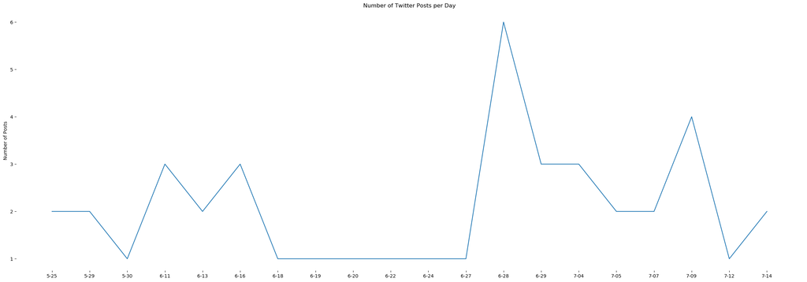

```python
tweets = feather.read_dataframe( "tweets" )

hardrock = tweets[tweets.screen_name == 'HardRockHCAC']

times = hardrock["created_at"]

dates = []

for post in times:
    post = str(post)
    dates.append(post[:post.find(" ")])
dates

dates_posted = list(set(dates))
dates_posted = sorted(dates_posted, key=lambda d: tuple(map(int, d.split('-'))))

number_of_posts = []
new_dates = []
for date in dates_posted:
    y = dates.count(date)
    number_of_posts.append(y)
    date = date[6:]
    new_dates.append(date)

dates_posted = new_dates

import matplotlib.pyplot as plt; plt.rcdefaults()
import numpy as np
import matplotlib.pyplot as plt

y_pos = np.arange(len(dates_posted))

fig, ax = plt.subplots(figsize=(30,10))
plt.plot(dates_posted, number_of_posts)
plt.xticks(y_pos, dates_posted)
plt.ylabel('Number of Posts')
plt.title('Number of Twitter Posts per Day')

ax.spines['top'].set_visible(False)
ax.spines['right'].set_visible(False)
ax.spines['bottom'].set_visible(False)
ax.spines['left'].set_visible(False)

plt.savefig("hard_rock_posts.png")

plt.show()
```